# Excercise - Lecture 2

Giuseppe Ragusa

12 September, 2016

# Goodness of Fit VS Predictive Power?

$$\begin{equation}
\nonumber
y_i = f(x_i) + \epsilon_i
\end{equation}$$

with $\epsilon_i$ random noise.

How can we find $f(x_{1,i},x_{2,i}, ..., x_{k,i})$ for a certain covariates matrix X in the information set?

Minimize the error?

$$\begin{equation}
\nonumber
\hat{f}(X_i) = \underset{f}{\operatorname{argmin}} E[(y_i - f(X_i))^2] ?
\end{equation}$$

One possible solution is to find the argument that minimize the sum of squared residuals, assuming that the predictor belong to a certain class of function (e.g. linear).

# Or maybe…

($\textbf{Y}_i, \textbf{X}_i$) are future observations.

$$\begin{equation}
\nonumber
E[(\textbf{Y}_i - \hat{f}(\textbf{X}_i))^2] = E[(y_i - \hat{f}(X_i))^2] + g(\epsilon_i)
\end{equation}$$

Is $g(\epsilon_i) = 0$ ?

Efron (2004):

“The assessment of predictive accuracy is a form of bias estimation: ERR, the apparent error, is downward biased for the true predictive error.”

$g(\epsilon_i) > 0$ $\forall \hat{f}$ (and most of the loss functions).

# Overfitting VS Underfitting

- Overfitting occurs when a statistical model or machine learning algorithm captures the noise of the data.
- Underfitting occurs when the model does not capture the trend of the data.

Overfitting occurs when the model is too flexible, capturing too much in-sample variance. It usually leads to:

- High Mean Squared Prediction Error (MSE on new observations).
- Low Mean Squared Error on the training data.

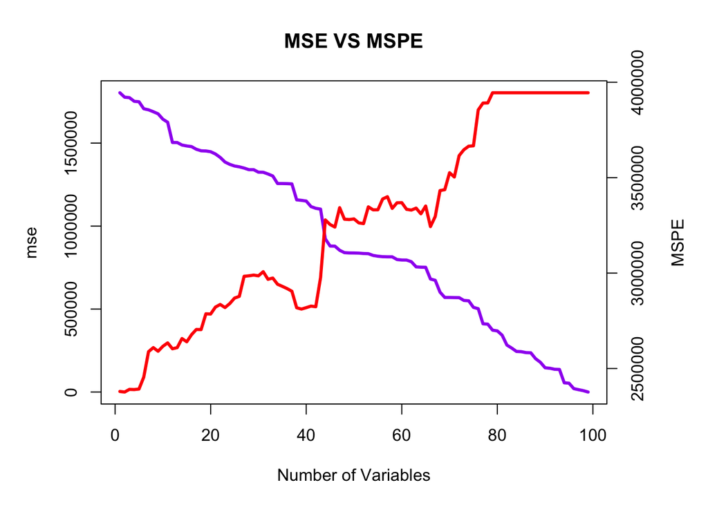

# The Bias-Variance trade off

$$\begin{equation}
E[(Y - \hat{f}(x))^2]
= \sigma_\epsilon^2 + Var(\hat{f}(x)) + E[f(x) - E[\hat{f}(x)]]^2
\end{equation}$$

The results come from the fact that $Var(Z) = E[Z^2] - E[Z]^2$.

The first term of the equation is random noise. The second term is the variance of the estimator and the last term is the bias squared.

- Low Bias $\rightarrow$ high flexibility $\rightarrow$ high variance
- Low Variance $\rightarrow$ low flexibility $\rightarrow$ high bias

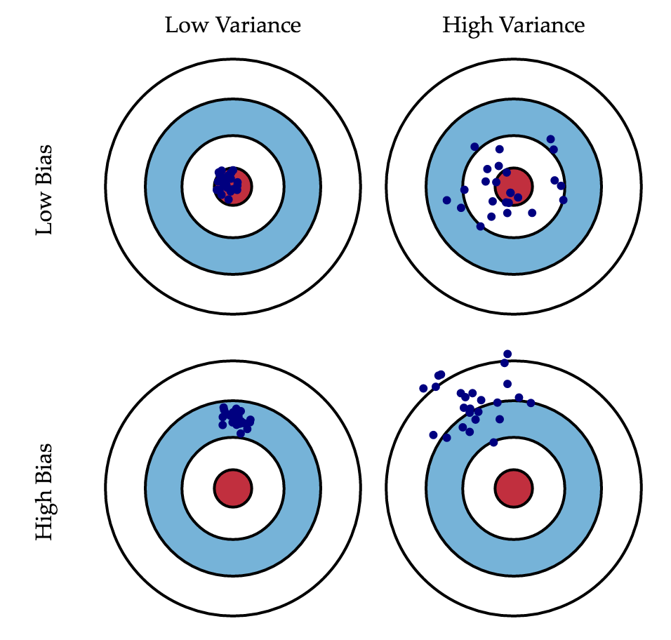

# Complexity and bias-variance trade-off

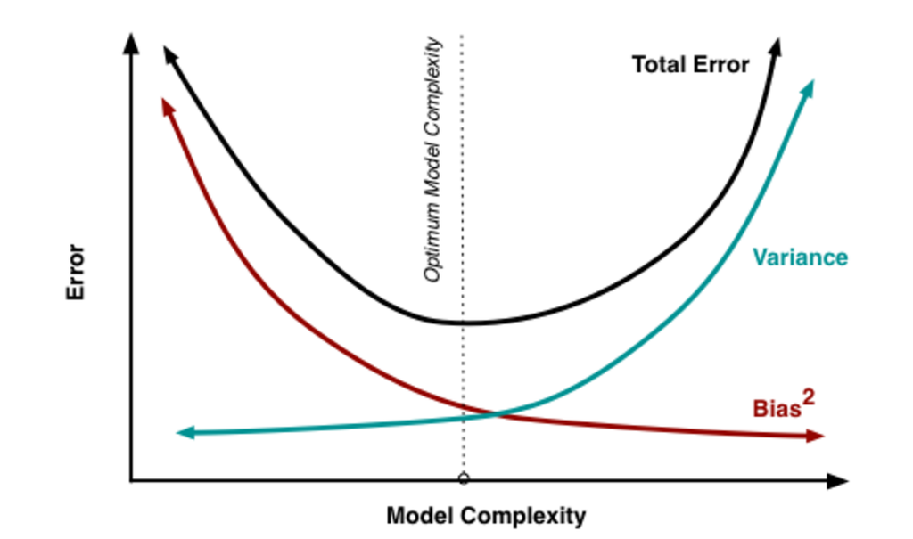

# How to compute the MSPE?

- Test-Training Set
- K fold Cross Validation
- Leave one out Cross Validation

Test-Training Set:

- Divide the data in two subsets
- Use one of them (training set) to build the model
- Make predictions in the other set

## Example - Practice

Data Generating Process:

For this example we generate 20 input variables, independently and uniformly distributed between -30 and 30. Then, we construct a dependent variable such that y $\sim$ 3 + 5*V20 and we add some random noise.

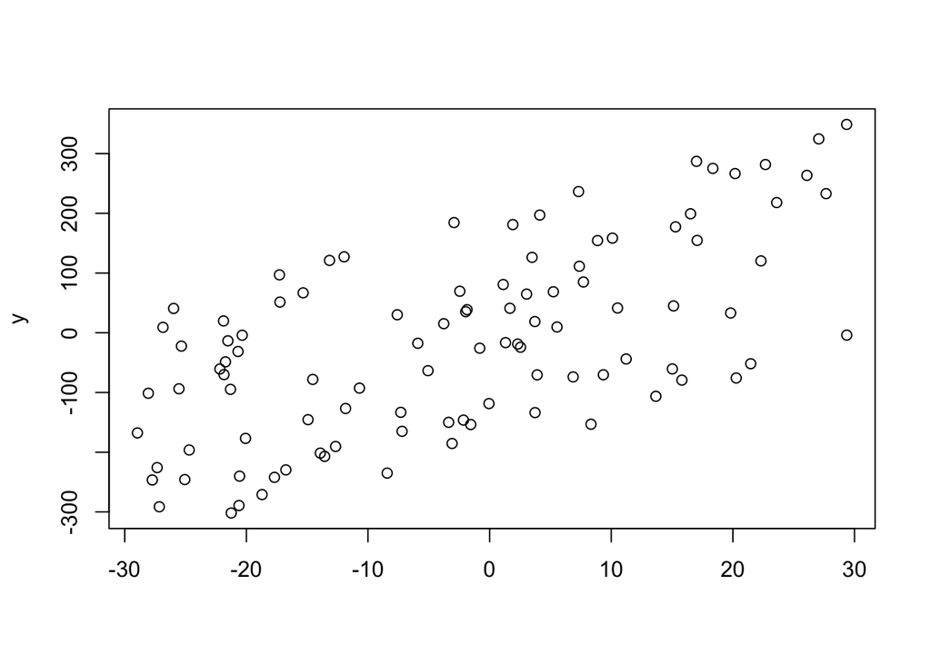

```r
## Generate a set of input variable

set.seed(123)
n <- 100
p <-  20
x <- matrix(runif(n*p, min=-30,max=30), n , p)

## Generate the output variable as a linear combination of x

## With jitter() you add random noise
y <-  jitter(3 + 5*x[,20], factor=10000)

## Look at the relationship

plot(cbind(x[,20],y))
```

```r
## Construct a linear model with all the variables

full <- lm(y~x) ## All variables
null <- lm(y~1) ## No variables

truth <- lm(y~x[,20]) ## true relationship

## Evaluate the MSE of each model


mse1 <- mean((y-predict(full))^2)
mse2 <- mean((y-predict(null))^2)
mse3 <- mean((y-predict(truth))^2)

print(cbind(mse1,mse2,mse3))
```

```
##          mse1     mse2     mse3
## [1,] 12169.91 24196.81 14422.44
```

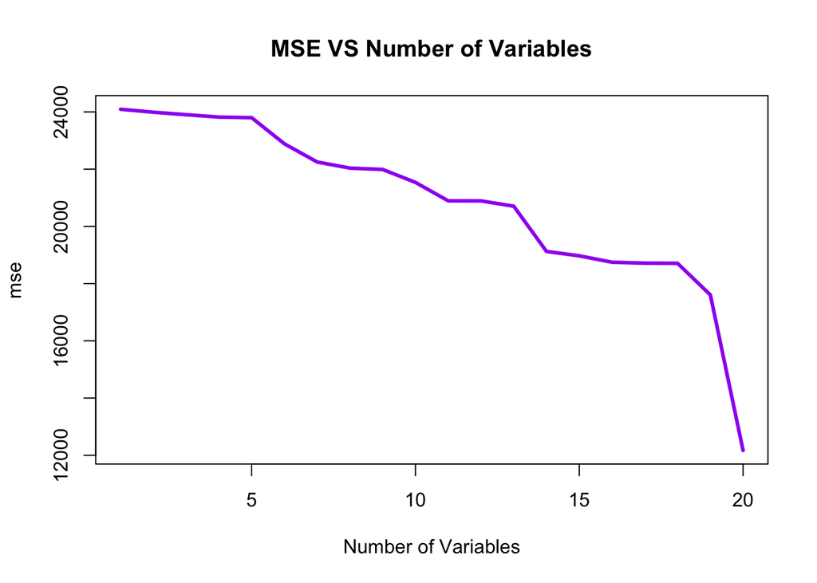

```r
## See the behaviour of the mse in function of the number of variables

## store MSE, construct each regression on columns of X

mse <- rep(NA, length=20)
for (i in 1:20){
  data <- x[,c(1:i)]
  reg <- lm(y~data)
  mse[i] <- mean((y-predict(reg))^2)

}

plot(cbind(c(1:20), mse),  type="n", main="MSE VS Number of Variables", xlab="Number of Variables")

lines(cbind(c(1:20), mse), col="purple", lwd=3)
```

```r
## Repeat the process but now with a test and training set



set.seed(123)

## Pick randomly 1/5th of observastions
ii <- sample(nrow(x), floor(nrow(x)/5))

## Built a test and training set

data.te <- x[ii, ]
data.tr <- x[-ii,]
y.te <- y[ii]
y.tr <- y[-ii]


full <- lm(y.tr~data.tr) ## All variables
null <- lm(y.tr~1) ## No variables

truth <- lm(y.tr~data.tr[,20]) ## true relationship

## Evaluate the MSE of each model (again)


mspe1 <- mean((y.te-predict(full, newx=data.te))^2)
mspe2 <- mean((y.te-predict(null, newx= data.te))^2)
mspe3 <- mean((y.te-predict(truth, newx=data.te))^2)

print(cbind(mspe1,mspe2,mspe3))
```

```
##         mspe1    mspe2    mspe3
## [1,] 32426.17 20267.25 30691.77
```

```r
## Compare
print(cbind(mse1,mse2,mse3))
```

```
##          mse1     mse2     mse3
## [1,] 12169.91 24196.81 14422.44
```

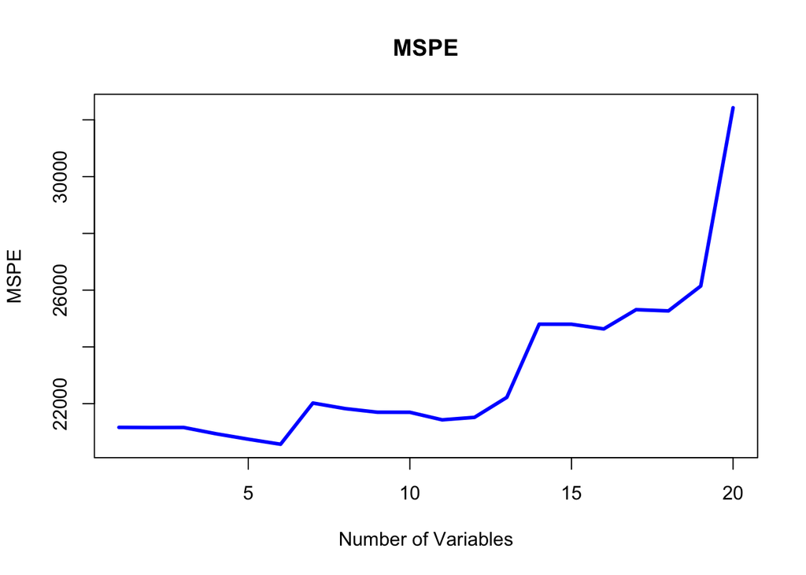

```r
## store MSE, construct each regression on columns of X

mspe <- rep(NA, length=20)
for (i in 1:20){
  data <- data.tr[,c(1:i)]
  reg <- lm(y.tr~data)
  mspe[i] <- mean((y.te-predict(reg, newx = data.te[,c(1:i)]))^2)

}



plot(cbind(c(1:20), mspe),  type="n", main="MSPE", xlab="Number of Variables", ylab="MSPE")

lines(cbind(c(1:20), mspe), col="blue", lwd=3)
```

The trade-off between the number of observations in test and traning set:

- The more the observations in the test set, the lower the variance of the MSPE, but the higher the bias
- The more the observations in the training set, the lower the bias, but the higher the variance of the MSPE

Could you tell why?

# K-folds Cross Validation

- Divide randomly the observations in k folds
- Use k-1 folds as a training set
- Make the predictions and compute the MSPE on the remaining fold
- Repeat the process for each fold
- Use the mean of each MSE as an estimator of the MSPE

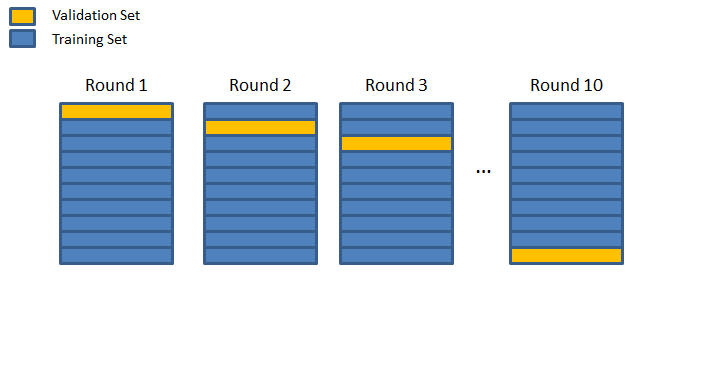

**Leave-one-out Cross-Validation**:

- Use n-1 observations as a training set
- Make the predictions and compute the MSPE on the remaining observation
- Repeat the process n times
- Use the mean of each MSE as an estimator of the MSPE

Leave-one-out Cross-Validation has the highest variance but the lowest bias. It is a valid alternative to K-folds when cross validation is computational intensive:

$$\begin{equation}
GCV(\hat{Y}) = \frac{1}{N}{\frac{\sum (y_i - \hat{f}(x_i))}{(1 - trace(S)/N)}}
\end{equation}$$

Where $\hat{Y} = SY$ , S is the regression matrix and it is independent on Y. \

Generally we will use K-folds Cross Validation.

# CV: Example

```r
forestfires <- read.csv("./data/forestfires.csv")

n <- nrow(forestfires)
k <- 5
set.seed(123)
y <- forestfires$area
ii <- sample(rep(1:k, length= n))
pr1 <- pr2  <- array(0, k)
mspe1 <- mspe2 <- array(0, k)

  for (j in 1:k){
    hold <- (ii == j)
    train <- (ii != j)

    reg2 <- lm(area~temp+day+wind+rain, data=forestfires[train,])
    reg1 <- lm(area~temp, data=forestfires[train,] )

    pr1[hold] <- predict(reg2, newdata= forestfires[hold,])
    pr2[hold] <- predict(reg1, newdata= forestfires[hold,])

  mspe1[j] <- mean((pr1 - y)^2, na.rm = TRUE)
  mspe2[j] <- mean((pr2 - y)^2, na.rm = TRUE)
}
```

## Exercise

- Generate 99 independent variables uniformly distributed between -100 and 100 of size 100 observations each.
- Generate the dependent variable y = 3 + 10*V99, where V99 is the last covariate and add some noise
- Construct a linear model with no variables, all the variables and only the variable V99
- Compute the MSE of each model

Hint: for the first two points code is provided in the next slide

```r
set.seed(123)
n <- 100
p <-  99
x <- matrix(runif(n*p, min=-100,max=100), n , p)

## Generate the output variable as a linear combination of x

## With jitter() you add random noise
y <-  jitter(3 + 10*x[,99], factor=10000)
```

- Pick from your data only 1/5th random observations
- Use the remaining 4/5th observations to rebuild the three model
- Make prediction on the 1/5th observations
- What do you observe now?

Hint: for the first point code is provided.

```r
## Pick randomly 1/5th of observastions
ii <- sample(nrow(x), floor(nrow(x)/5))

## Built a test and training set

data.te <- x[ii, ]
data.tr <- x[-ii,]
y.te <- y[ii]
y.tr <- y[-ii]
```

# Optional Challenge

- Build 99 different models including from 1 to 99 input variables on training data (4/5th observations)
- For each model compute the MSPE on the remaining 1/5th (test data)
- Plot the MSPE in function of the number of variables
- Repeat the same process using all the observations and compute the MSE on the in-sample observations

Hint: you may prefer to use a for-loop.

## Solution

```r
## Construct a linear model with all the variables

full <- lm(y~x) ## All variables
null <- lm(y~1) ## No variables

truth <- lm(y~x[,99]) ## true relationship

## Evaluate the MSE of each model


mse1 <- mean((y-predict(full))^2)
mse2 <- mean((y-predict(null))^2)
mse3 <- mean((y-predict(truth))^2)

print(cbind(mse1,mse2,mse3))
```

```
##              mse1    mse2    mse3
## [1,] 7.852797e-23 1812712 1551349
```

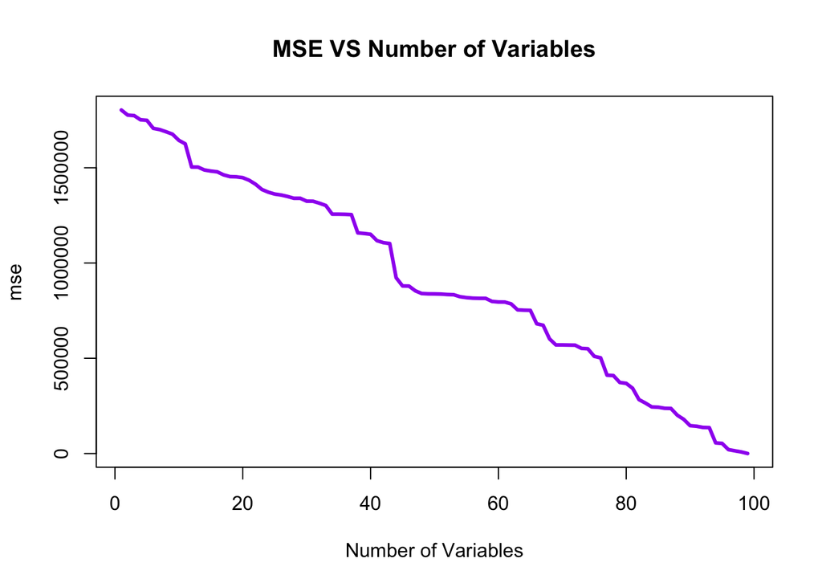

```r
## See the behaviour of the mse in function of the number of variables

## store MSE, construct each regression on columns of X

mse <- rep(NA, length=99)
for (i in 1:99){
  data <- x[,c(1:i)]
  reg <- lm(y~data)
  mse[i] <- mean((y-predict(reg))^2)

}

plot(cbind(c(1:99), mse),  type="n", main="MSE VS Number of Variables", xlab="Number of Variables")

lines(cbind(c(1:99), mse), col="purple", lwd=3)
```

```r
## Repeat the process but now with a test and training set



set.seed(123)

## Pick randomly 1/5th of observastions
ii <- sample(nrow(x), floor(nrow(x)/5))

## Built a test and training set

data.te <- x[ii, ]
data.tr <- x[-ii,]
y.te <- y[ii]
y.tr <- y[-ii]


full <- lm(y.tr~data.tr) ## All variables
null <- lm(y.tr~1) ## No variables

truth <- lm(y.tr~data.tr[,99]) ## true relationship

## Evaluate the MSE of each model (again)


mspe1 <- mean((y.te-predict(full, newx=data.te))^2)
mspe2 <- mean((y.te-predict(null, newx= data.te))^2)
mspe3 <- mean((y.te-predict(truth, newx=data.te))^2)

print(cbind(mspe1,mspe2,mspe3))
```

```
##        mspe1   mspe2   mspe3
## [1,] 3945007 2349223 2688203
```

```r
## Compare
print(cbind(mse1,mse2,mse3))
```

```
##              mse1    mse2    mse3
## [1,] 7.852797e-23 1812712 1551349
```

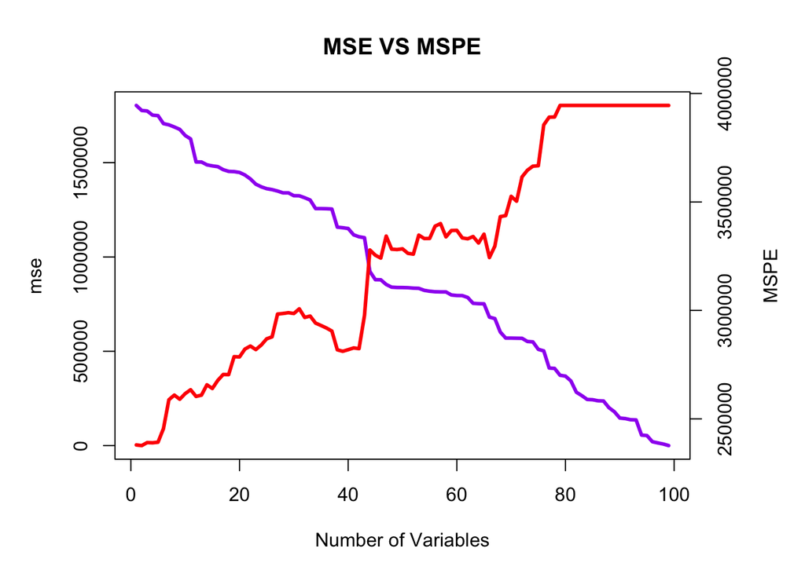

```r
## store MSE, construct each regression on columns of X

mspe <- rep(NA, length=99)
for (i in 1:99){
  data <- data.tr[,c(1:i)]
  reg <- lm(y.tr~data)
  mspe[i] <- mean((y.te-predict(reg, newx = data.te[,c(1:i)]))^2)

}





par(mar = c(5,5,4,5))
plot(cbind(c(1:99), mse),  type="n", main="MSE VS MSPE", xlab="Number of Variables")
lines(cbind(c(1:99), mse), col="purple", lwd=3)


par(new = T)
plot(cbind(c(1:99), mspe),  type="n", main=NA, xlab=NA, ylab=NA, axes=F)
axis(side = 4)
mtext(side = 4, line = 3, 'MSPE')
lines(cbind(c(1:99), mspe), col="red", lwd=3)
```